# Psychiatric Hospital

# Probabilistic Simulation

## Clinical service success

We use *clinical service* as an generic term for all kinds of treatment provided to patients in a psychiatric hospital. This includes in particular *diagnosis and prescription*, *psychotherapy*, and *nursing care*.

We simplify clinical service success to a binary outcome: either the patient recovers (**SUCCESS**) or not (**FAIL**).

In reality, the quantification of clinicialservice success is not as simple. In a hospital context, success could be quantified by the reason for discharge (e.g., full recovery, partial recovery, transfer to another facility, etc.). In a psychotherapy context, treatment success can be measured by clinical assessement scales for mental illness before and after treatment.

Not all mechanisms of functioning of psychotherapy and other treatment of patients is known, at least not deterministally known. Therefore, the effectiveness of clinical services is measured with randomized controlled trials. Through randomization, a causal relationship between treatment and treatment success can be established. However, this does neither establish a mechanistic explanation nor can it determine causal effectiveness of the clinical service for individual patients. Therefore, a probabilistic model of clinical service success is appropriate.

Again, we simplify the clinical service to three categories: **effective**, **ineffective/harmful**, and **placebo/low-level**.

In reality, there are many more gradations of effectiveness of clinical services. However, the three categories capture the essential differences in treatment effectiveness. The basic idea of this model is that effective clinical service have a high probability of success but also placebo services can lead to a success but with a lower probability. Finally, we assume that an ineffective service has an even lower probability of success than a placebo service.

So, our simplified model builds on the definition of these probabilities:

- $P(\text{success} \mid \text{effective service}) = p^\text{eT}$ *probability of success under effective service*
- $P(\text{success} \mid \text{placebo service}) = p^\text{pT}$ *probability of success under placebo/low-level service*
- $P(\text{success} \mid \text{ineffective service}) = p^\text{iT}$ *probability of success under ineffective/harmful service*

and it holds that $1 > p^\text{eT} > p^\text{pT} > p^\text{iT} > 0$. The sharp inequalities with repsect to zero and one signify that even an effective service can fail and ineffective services can sometimes lead to success (e.g., through spontaneous remission of the illness).

## Actions of the healthcare professionals

What determines effective, placebo, and ineffective service of health care professionals? In this model, we want to boil it down to two characteristics: *self-efficacy expectation* (*self-efficacy* for short in the following) and *competence*.

The total treatment of patients in a psychiatric hospital is provided by a **team** of professionals. Prototypically,

- a **psychiatrist**, mainly reposible for diagnosis and prescription,
- a **psychotherapist**, mainly repsonsible for applying psychotherapy, and
- a **nurse** mainly responsible for psychiatric care.

# Simplified version with team as a whole

Each professional has his/her own self-efficacy and competence. However, as a first version of the probabilistic model we lump them together assuming a team self-efficacy and a team competence.

With this simplified assumption and our general setup, we assume:

- *Self-efficacy* is the probability of not applying a placebo/low-level service but aiming for an effecitive one, however it could turn out to be an ineffective/harmful one. $P(\text{effective} \cup \text{ineffective}) = P(\text{non-placebo}) =p^\text{SE}$ and $P(\text{placebo}) = 1 - p^\text{SE}$.
- *Competence* applies only when the professional (or team) aims for a non-placebo service. Then it is the probability of applying an effective and not an ineffective/harmful for the patient, given that a non-placebo treatment is selected. $P(\text{effective} \mid \text{effective} \cup \text{ineffective}) = p^\text{CO}$ and $P(\text{ineffective} \mid \text{effective} \cup \text{ineffective}) = 1 - p^\text{CO}$.

$P(\text{effective})$, $P(\text{ineffective})$, and $P(\text{placebo})$ can be derived from the two exogenously given probabilities $p^\text{SE}$ and $p^\text{CO}$:

$$\begin{align}
P(\text{effective}) &= p^\text{SE} p^\text{CO} \\
P(\text{placebo}) &= 1 - p^\text{SE} \\
P(\text{ineffective}) &= p^\text{SE}(1 - p^\text{CO})\end{align}$$

```r
library(tidyverse)
library(numDeriv)
# Professional probabilities
p_SE <- 0.8 # Self-efficacy
p_CO <- 0.7 # Competence
# Treatment success probabilities
p_eS <- 0.8 # Probability of success with appropriate treatment
p_pS <- 0.5 # Probability of success with placebo
p_iS <- 0.2 # Probability of success with inappropriate treatment
# Treatment doing probabilities
p_eT <- function(p_SE, p_CO) p_SE * p_CO # Probability of doing an effective treatment
p_pT <- function(p_SE, p_CO) 1 - p_SE # Probability of doing a placebo treatment
p_iT <- function(p_SE, p_CO) p_SE * (1 - p_CO) # Probability of doing an ineffective treatment
# Calculate overall probability of successful treatment
P_success <- function(p_SE, p_CO, p_eS = 0.8, p_iS = 0.2, p_pS = 0.5) {
  p_pT(p_SE, p_CO) * p_pS + p_iT(p_SE, p_CO) * p_iS + p_eT(p_SE, p_CO) * p_eS
}
```

Probability of doing effective treatment.

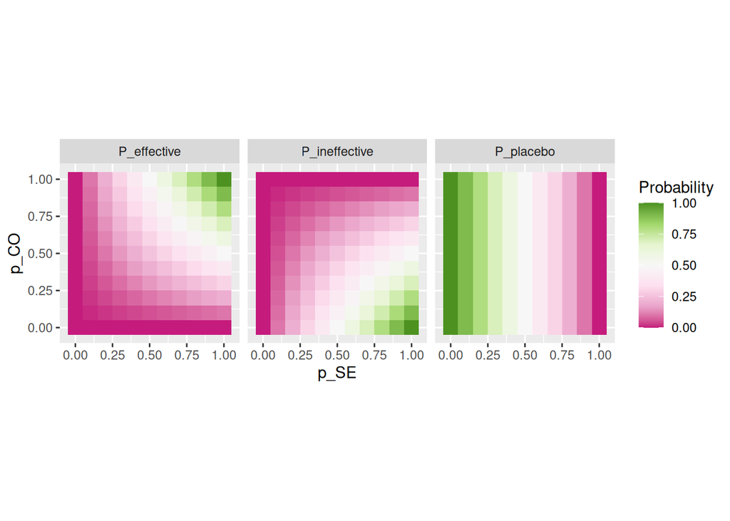

```r
expand_grid(
  p_SE = seq(0, 1, by = 0.1),
  p_CO = seq(0, 1, by = 0.1)
) |> # Calculate the probability of success
  mutate(P_effective = p_eT(p_SE, p_CO)) |>
  mutate(P_placebo = p_pT(p_SE, p_CO)) |>
  mutate(P_ineffective = p_iT(p_SE, p_CO)) |>
  pivot_longer(
    cols = c(P_placebo, P_ineffective, P_effective),
    names_to = "Treatment_Type",
    values_to = "Probability"
  ) |>
  ggplot(aes(x = p_SE, y = p_CO, fill = Probability)) +
  geom_tile() +
  facet_wrap(~Treatment_Type) +
  scale_fill_distiller(palette = "PiYG", direction = 1, limits = c(0, 1)) +
  coord_fixed()
```

We want to know $P(\text{success} \mid \text{professional/team has } p^\text{SE}\text{ and }p^\text{CO})$ which we may abbreviate as $P(\text{success})$. Given the notions of the five exogenously given probabilities above it is:
$$\begin{align}
P&(\text{success} \mid \text{Professional has } p^\text{SE}\text{ and }p^\text{CO}) \\
=& P(\text{placebo})p^\text{pT} + \\
& P(\text{non-placebo})P(\text{ineffective} \mid \text{non-placebo})p^\text{iT} + \\
& P(\text{non-placebo})P(\text{effective} \mid \text{non-placebo})p^\text{aT} \\
= &\underbrace{(1 - p^\text{SE})p^\text{Pl}}_\text{(i)} + \underbrace{p^\text{SE}(1 - p^\text{CO})p^\text{iT}}_\text{(ii)} + \underbrace{p^\text{SE} p^\text{CO} p^\text{aT}}_\text{(iii)}
\end{align}$$

It is the sum of the probabilities of three mutually exclusive events: (i) the professional does a placebo/low-level treatment and the patient recovers, (ii) the professional selects an ineffective non-placebo treatment but nevertheless the patient recovers, and (iii) the professional selects an efective non-placebo treatment and the patient recovers.

Numerical example:

Professional Treatment probabilities:  
$p^\text{SE} = 0.8$, $p^\text{CO} = 0.7$

Treatment Outcome probabilities:  
$p^\text{eS} = 0.8$ $p^\text{iS} = 0.2$, $p^\text{pS} = 0.5$

$$P(\text{success}) = \underbrace{0.1}_\text{(i)} + \underbrace{0.048}_\text{(ii)} + \underbrace{0.448}_\text{(iii)} = 0.596$$

## Interventions on self-efficacy and competence

We can map the probability of successful treatment over a grid of self-efficacy and competence values and compute the gradients (black arrows) to see how changes in self-efficacy and competence affect the probability of successful treatment.

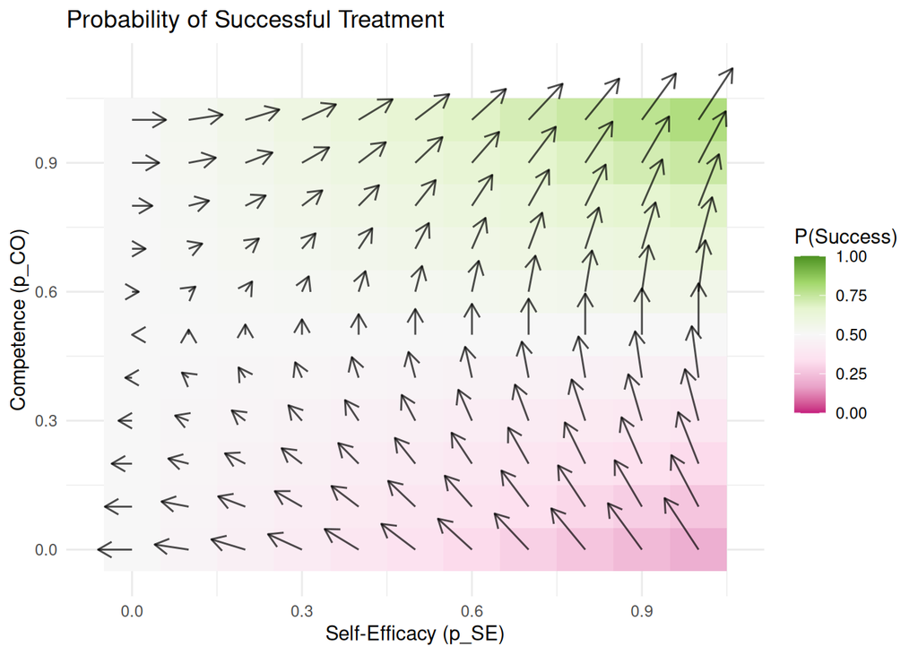

```r
# Create a grid of self-efficacy and competence values
gradient_P_success <- function(params, p_eS, p_iS, p_pS) {
  p_SE <- params[1]
  p_CO <- params[2]
  P_success(p_SE, p_CO, p_eS, p_iS, p_pS)
}

plot_heatmap_gradient <- function(p_eS, p_iS, p_pS) {
  se_co_grid <- expand_grid(
    p_SE = seq(0, 1, by = 0.1),
    p_CO = seq(0, 1, by = 0.1)
  ) |> # Calculate the probability of success
    mutate(P_success = P_success(p_SE, p_CO, p_eS, p_iS, p_pS)) |>
    # Compute gradients
    rowwise() |>
    mutate(
      grad = list(grad(
        gradient_P_success,
        c(p_SE, p_CO),
        p_eS = p_eS,
        p_iS = p_iS,
        p_pS = p_pS
      ))
    ) |>
    ungroup() |>
    mutate(
      dP_dSE = grad |> map_dbl(\(x) x[[1]] |> unlist()),
      dP_dCO = grad |> map_dbl(\(x) x[[2]] |> unlist()),
    ) |>
    mutate(
      arrow_scale = 0.2,
      dP_dSE_scaled = dP_dSE * arrow_scale,
      dP_dCO_scaled = dP_dCO * arrow_scale
    ) |> # Plot the results
    ggplot(aes(x = p_SE, y = p_CO, fill = P_success)) +
    geom_tile() +
    geom_segment(
      aes(xend = p_SE + dP_dSE_scaled, yend = p_CO + dP_dCO_scaled),
      arrow = arrow(length = unit(0.12, "inches")),
      color = "black",
      alpha = 0.7
    ) +
    # diverging pallette
    scale_fill_distiller(palette = "PiYG", direction = 1, limits = c(0, 1)) +
    labs(
      title = "Probability of Successful Treatment",
      x = "Self-Efficacy (p_SE)",
      y = "Competence (p_CO)",
      fill = "P(Success)"
    ) +
    theme_minimal()
}
g <- plot_heatmap_gradient(p_eS, p_iS, p_pS)
g
```

# Psychiatrist, Psychotherapist, Nurse as separate professionals

In reality, the clinical service is provided by a team of professionals.

Simplified to the essence, the patients undergoes the clinical service in this way

1. The physician makes a diagnosis and a prescription.
2. Based on this, a psychotherapist applies psychotherapy.
3. The nurse provides psychiatric nursing care, supporting the patient in life in the clinic and supporting prescribed therapy.

All three professionals contribute to the treatment being finally effective, placebo, and ineffective. However, the different professional services build on each other. First, the physician can make an effective, placebo, or ineffective/harmful diagnosis and prescription. Second, the psychotherapitst may change this status for the better or the worse. For example, the therapist can change a placebo prescription to an effective therapy by applying independent non-diagnosis-related competences. Similarly, a psychotherapist can change an effective prescription into an ineffective treatment either through large incompentce or through a personal preference for therapeutical methods which do not fit to the patient and are even harmful under its current condition (e.g. by contributing to chronification or triggering additional mental problem). Third, the nurse can also change the status of the treatment through his/her care. For example, a nurse can support the patient in taking the medication and supporting the psychotherapy in day-to-day life. In a similar way, as the therapist, the nurse can bring an effective, placebo, or ineffective treatment to another stage for the better or the worse.

For our probabilistic treatment

For the psychiatrist (1) we can assume the same as above:

$$\begin{align}
P(\text{1\_effective}) &= p^\text{SE}_1 p^\text{CO}_1 \\
P(\text{1\_placebo}) &= 1 - p^\text{SE}_1 \\
P(\text{1\_ineffective}) &= p^\text{SE}_1(1 - p^\text{CO}_1)
\end{align}$$

However, the psychotherapist outcome service outcome depends on the input of the psychiatrist. So, we have to specify the conditional probabilities:

$$\begin{align}
P(\text{2\_effective} \mid \text{1\_effective}) \\
P(\text{2\_placebo} \mid \text{1\_effective}) \\
P(\text{2\_ineffective} \mid \text{1\_effective}) \\ \hline
P(\text{2\_effective} \mid \text{1\_placebo}) \\
P(\text{2\_placebo} \mid \text{1\_placebo}) \\
P(\text{2\_ineffective} \mid \text{1\_placebo}) \\ \hline
P(\text{2\_effective} \mid \text{1\_ineffective}) \\
P(\text{2\_placebo} \mid \text{1\_ineffective}) \\
P(\text{2\_ineffective} \mid \text{1\_ineffective}) \\
\end{align}$$

Let us focus on the case of an effective diagnosis/prescription (1_effective). In principle, we keep the same logic as above: The probability to do a non-placebo treatment increases with self-efficacy and the probability to do an effective treatment given it is non-placebo increases with competence. However, given that the diagnosis and prescription is already effective, both probabilities should be larger than in the standard case.

For the probability of effective treatment given a non-placebo treatment applies, we provide to versions how to model this probability given $p_2^\text{CO}$

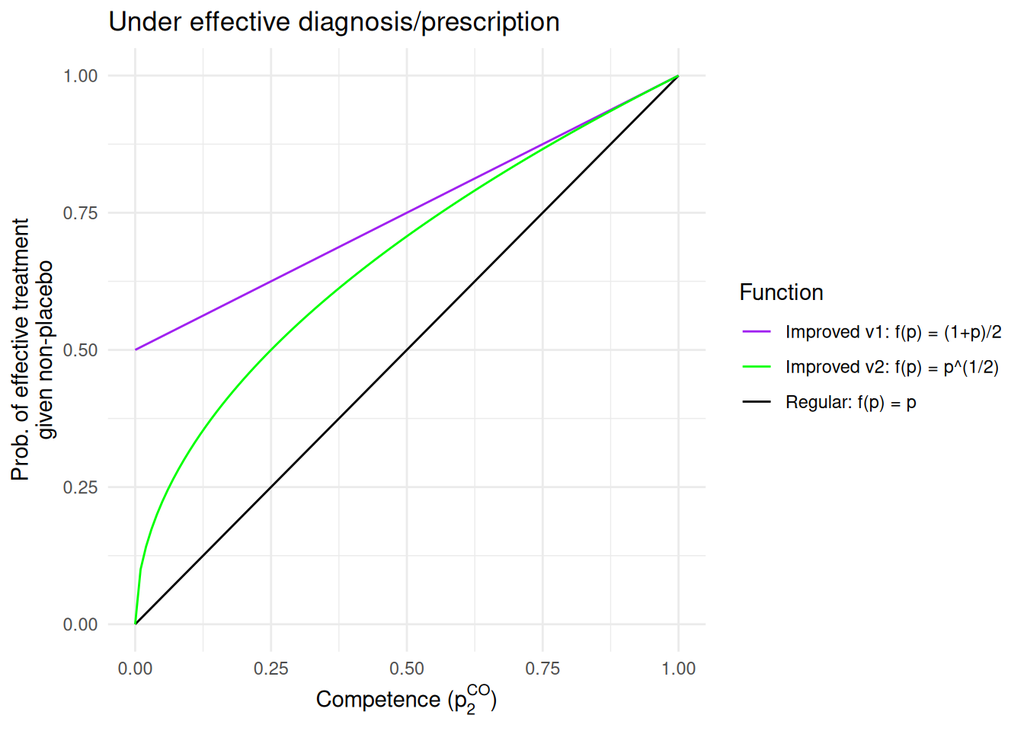

```r
ggplot() +
  geom_function(fun = \(x) x, aes(color = "Regular: f(p) = p")) +
  geom_function(
    fun = \(x) (x + 1) / 2,
    aes(color = "Improved v1: f(p) = (1+p)/2")
  ) +
  geom_function(
    fun = \(x) x^(1 / 2),
    aes(color = "Improved v2: f(p) = p^(1/2)")
  ) +
  scale_color_manual(
    name = "Function",
    values = c(
      "Regular: f(p) = p" = "black",
      "Improved v1: f(p) = (1+p)/2" = "purple",
      "Improved v2: f(p) = p^(1/2)" = "green"
    )
  ) +
  labs(
    x = bquote("Competence (" * p[2]^CO * ")"),
    y = "Prob. of effective treatment\ngiven non-placebo",
    title = "Under effective diagnosis/prescription"
  ) +
  theme_minimal()
```

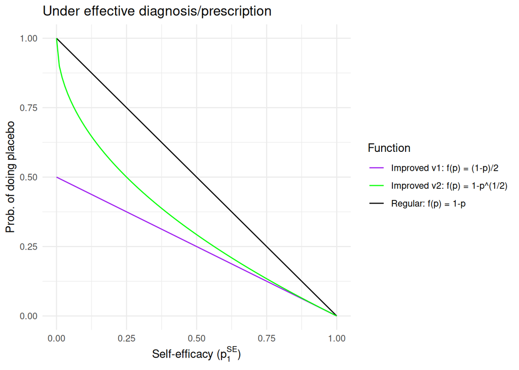

```r
ggplot() +
  geom_function(fun = \(x) 1 - x, aes(color = "Regular: f(p) = 1-p")) +
  geom_function(
    fun = \(x) (1 - x) / 2,
    aes(color = "Improved v1: f(p) = (1-p)/2")
  ) +
  geom_function(
    fun = \(x) 1 - x^(1 / 2),
    aes(color = "Improved v2: f(p) = 1-p^(1/2)")
  ) +
  scale_color_manual(
    name = "Function",
    values = c(
      "Regular: f(p) = 1-p" = "black",
      "Improved v1: f(p) = (1-p)/2" = "purple",
      "Improved v2: f(p) = 1-p^(1/2)" = "green"
    )
  ) +
  labs(
    x = bquote("Self-efficacy (" * p[1]^SE * ")"),
    y = "Prob. of doing placebo",
    title = "Under effective diagnosis/prescription"
  ) +
  theme_minimal()
```

So, the probabilities for the psychotherapist given an **effective diagnosis/prescription of the psychiatrist could be (v1):

$$\begin{align}
P(\text{2\_effective} \mid \text{1\_effective}) &= \frac{1 + p^\text{SE}_2}{2} \frac{1+p^\text{CO}_2}{2} & \\
P(\text{2\_placebo} \mid \text{1\_effective}) &= \frac{1 - p^\text{SE}_2}{2} & \\
P(\text{2\_ineffective} \mid \text{1\_effective}) &= \frac{1 + p^\text{SE}_2}{2} \frac{1-p^\text{CO}_2}{2} &
\end{align}$$

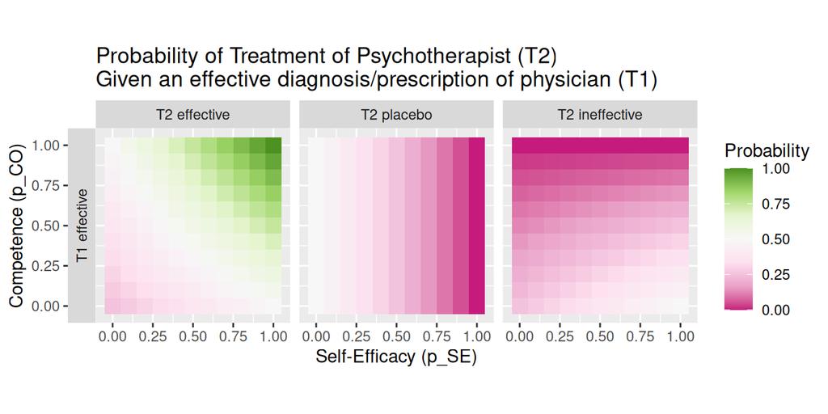

```r
p_v1 <- function(T2, T1, p_SE, p_CO) {
  T2 <- str_remove(T2, "T2 ") |> str_remove("/none")
  T1 <- str_remove(T1, "T1 ") |> str_remove("/none")
  case_when(
    T2 == "effective" & T1 == "effective" ~ ((1 + p_SE) / 2) * ((1 + p_CO) / 2),
    T2 == "placebo" & T1 == "effective" ~ (1 - p_SE) / 2,
    T2 == "ineffective" & T1 == "effective" ~ ((1 + p_SE) / 2) *
      ((1 - p_CO) / 2),
    T2 == "effective" & (T1 == "placebo" | T1 == "none") ~ p_SE * p_CO,
    T2 == "placebo" & (T1 == "placebo" | T1 == "none") ~ (1 - p_SE),
    T2 == "ineffective" & (T1 == "placebo" | T1 == "none") ~ p_SE * (1 - p_CO),
    T2 == "effective" & T1 == "ineffective" ~ p_SE * p_CO,
    T2 == "placebo" & T1 == "ineffective" ~ (1 - p_SE) * (1 - p_CO),
    T2 == "ineffective" & T1 == "ineffective" ~ 1 -
      p_SE * p_CO -
      (1 - p_SE) * (1 - p_CO)
  )
}
expand_grid(
  T1 = fct_inorder(c("T1 effective")),
  T2 = fct_inorder(c("T2 effective", "T2 placebo", "T2 ineffective")),
  p_SE = seq(0, 1, by = 0.1),
  p_CO = seq(0, 1, by = 0.1)
) |> # Calculate the probabilities
  mutate(Probability = p_v1(T2, T1, p_SE, p_CO)) |>
  ggplot(aes(x = p_SE, y = p_CO, fill = Probability)) +
  geom_tile() +
  facet_grid(T1 ~ T2, switch = "y") +
  scale_fill_distiller(palette = "PiYG", direction = 1, limits = c(0, 1)) +
  labs(
    title = "Probability of Treatment of Psychotherapist (T2)\nGiven an effective diagnosis/prescription of physician (T1)",
    x = "Self-Efficacy (p_SE)",
    y = "Competence (p_CO)",
  ) +
  coord_fixed()
```

For the case of a **placebo diagnosis/prescription**, we can assume the same probabilities as in the standard case.

$$\begin{align}
P(\text{2\_effective} \mid \text{1\_placebo}) &= p^\text{SE}_2 p^\text{CO}_2 & \\
P(\text{2\_placebo} \mid \text{1\_placebo}) &= 1 - p^\text{SE}_2 & \\
P(\text{2\_ineffective} \mid \text{1\_placebo}) &= p^\text{SE}_2(1 - p^\text{CO}_2) &
\end{align}$$

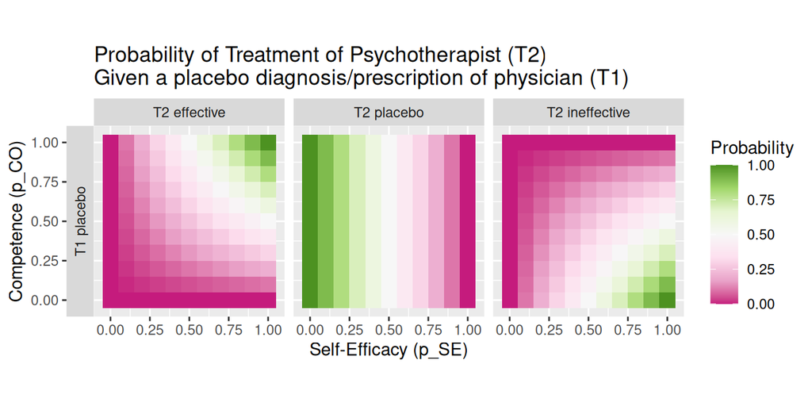

```r
expand_grid(
  T1 = fct_inorder(c("T1 placebo")),
  T2 = fct_inorder(c("T2 effective", "T2 placebo", "T2 ineffective")),
  p_SE = seq(0, 1, by = 0.1),
  p_CO = seq(0, 1, by = 0.1)
) |> # Calculate the probabilities
  mutate(Probability = p_v1(T2, T1, p_SE, p_CO)) |>
  ggplot(aes(x = p_SE, y = p_CO, fill = Probability)) +
  geom_tile() +
  facet_grid(T1 ~ T2, switch = "y") +
  scale_fill_distiller(palette = "PiYG", direction = 1, limits = c(0, 1)) +
  labs(
    title = "Probability of Treatment of Psychotherapist (T2)\nGiven a placebo diagnosis/prescription of physician (T1)",
    x = "Self-Efficacy (p_SE)",
    y = "Competence (p_CO)",
  ) +
  coord_fixed()
```

Given an **ineffective/harmful diagnosis/prescription** of the physician we see the probabilities for an effective therapy under high self-efficacy and competence as for the placebo treatment. However, for high probabilities of an ineffective treament we see two opposing options: It happesn likely with high self-efficacy and low competence as under a placebo diagnosis/prescription, bt we also see it likely to happen under low self-efficacy and high competence. In the case of low sel-efficacy, we assume that the therapist tends to obey the ineffecive prescription and with high competence the therapist is able to apply it. That way, higher competence can lead to a worse outcome than low competence under an ineffective/harmful diagnosis/prescription of the physician and low self-efficacy of the therapist.

In equations it looks like this:

$$\begin{align}
P(\text{2\_effective} \mid \text{1\_ineffective}) &= p^\text{SE}_2 p^\text{CO}_2 & \\
P(\text{2\_placebo} \mid \text{1\_ineffective}) &= (1 - p^\text{SE}_2)(1 - p^\text{CO}_2) & \\
P(\text{2\_ineffective} \mid \text{1\_ineffective}) &= 1 - p^\text{SE}_2 p^\text{CO}_2 - (1 - p^\text{SE}_2)(1 - p^\text{CO}_2) &
\end{align}$$

[figure not shown]

```r
expand_grid(
  T1 = fct_inorder(c("T1 ineffective")),
  T2 = fct_inorder(c("T2 effective", "T2 placebo", "T2 ineffective")),
  p_SE = seq(0, 1, by = 0.1),
  p_CO = seq(0, 1, by = 0.1)
) |> # Calculate the probabilities
  mutate(Probability = p_v1(T2, T1, p_SE, p_CO)) |>
  ggplot(aes(x = p_SE, y = p_CO, fill = Probability)) +
  geom_tile() +
  facet_grid(T1 ~ T2, switch = "y") +
  scale_fill_distiller(palette = "PiYG", direction = 1, limits = c(0, 1)) +
  labs(
    title = "Probability of Treatment of Psychotherapist (T2)\nGiven an effective diagnosis/prescription of physician (T1)",
    x = "Self-Efficacy (p_SE)",
    y = "Competence (p_CO)",
  ) +
  coord_fixed()
```

The following plot shows all three cases together:

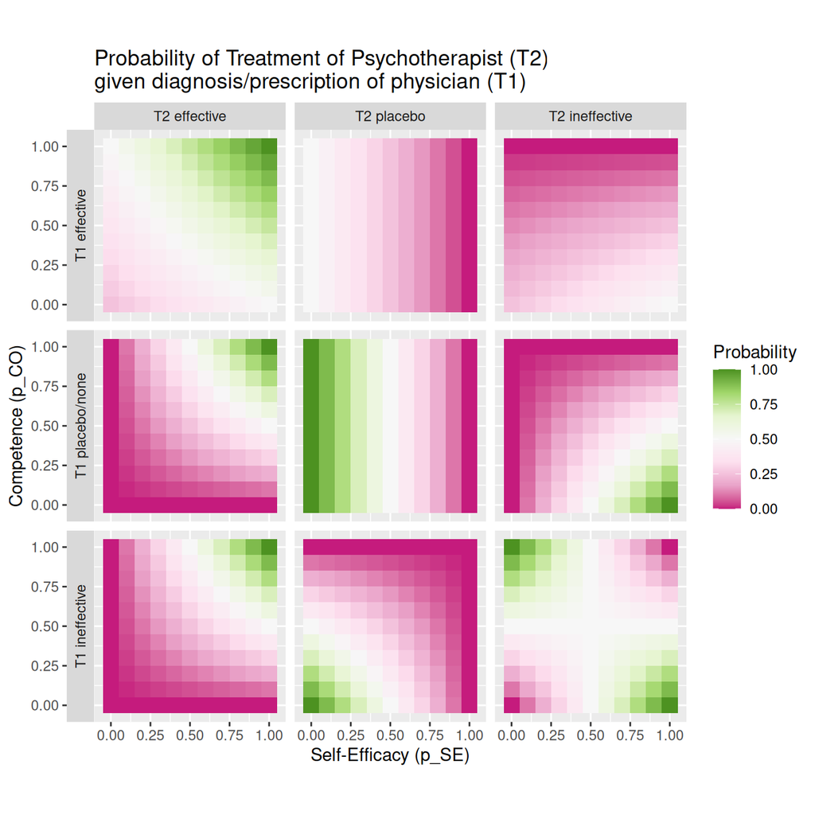

```r
expand_grid(
  T1 = fct_inorder(c("T1 effective", "T1 placebo/none", "T1 ineffective")),
  T2 = fct_inorder(c("T2 effective", "T2 placebo", "T2 ineffective")),
  p_SE = seq(0, 1, by = 0.1),
  p_CO = seq(0, 1, by = 0.1)
) |> # Calculate the probabilities
  mutate(Probability = p_v1(T2, T1, p_SE, p_CO)) |>
  ggplot(aes(x = p_SE, y = p_CO, fill = Probability)) +
  geom_tile() +
  facet_grid(T1 ~ T2, switch = "y") +
  scale_fill_distiller(palette = "PiYG", direction = 1, limits = c(0, 1)) +
  labs(
    title = "Probability of Treatment of Psychotherapist (T2)\ngiven diagnosis/prescription of physician (T1)",
    x = "Self-Efficacy (p_SE)",
    y = "Competence (p_CO)",
  ) +
  coord_fixed()
```

## Success probabilities for the psychotherapist given the diagnosis/prescription of the psychiatrist

With the different probabilities for the psychotherapist given the diagnosis/prescription of the psychiatrist, we can calculate the overall probability of successful treatment of the psychotherapist given the diagnosis/prescription of the psychiatrist, using the success probabilities of the different treatment types as defined above.

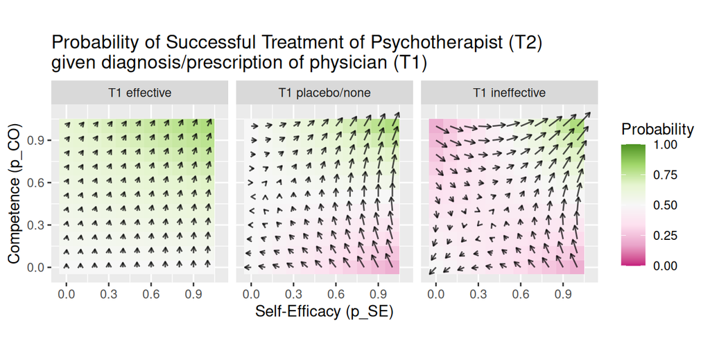

```r
p_eS <- 0.8 # Probability of success with appropriate treatment
p_iS <- 0.2 # Probability of success with inappropriate treatment
p_pS <- 0.5 # Probability of success with placebo
p_v1_S <- function(T1, p_SE, p_CO, p_eS, p_iS, p_pS) {
  p_v1("effective", T1, p_SE, p_CO) *
    p_eS +
    p_v1("placebo", T1, p_SE, p_CO) * p_pS +
    p_v1("ineffective", T1, p_SE, p_CO) * p_iS
}
gradient_P_success_T1T2 <- function(params, T1, p_eS, p_iS, p_pS) {
  p_SE <- params[1]
  p_CO <- params[2]
  p_v1_S(T1, p_SE, p_CO, p_eS, p_iS, p_pS)
}
expand_grid(
  T1 = fct_inorder(c("T1 effective", "T1 placebo/none", "T1 ineffective")),
  p_SE = seq(0, 1, by = 0.1),
  p_CO = seq(0, 1, by = 0.1)
) |> # Calculate the probabilities
  mutate(Probability = p_v1_S(T1, p_SE, p_CO, p_eS, p_iS, p_pS)) |>
  # Compute gradients
  rowwise() |>
  mutate(
    grad = list(grad(
      function(x) {
        gradient_P_success_T1T2(
          x,
          T1 = as.character(T1),
          p_eS = p_eS,
          p_iS = p_iS,
          p_pS = p_pS
        )
      },
      c(p_SE, p_CO)
    ))
  ) |>
  ungroup() |>
  mutate(
    dP_dSE = grad |> map_dbl(\(x) x[[1]] |> unlist()),
    dP_dCO = grad |> map_dbl(\(x) x[[2]] |> unlist()),
  ) |>
  mutate(
    arrow_scale = 0.2,
    dP_dSE_scaled = dP_dSE * arrow_scale,
    dP_dCO_scaled = dP_dCO * arrow_scale
  ) |> # Plot the results
  ggplot(aes(x = p_SE, y = p_CO, fill = Probability)) +
  geom_tile() +
  geom_segment(
    aes(xend = p_SE + 0.75 * dP_dSE_scaled, yend = p_CO + 0.8 * dP_dCO_scaled),
    arrow = arrow(length = unit(0.05, "inches")),
    color = "black",
    alpha = 0.7
  ) +
  facet_wrap(~T1) +
  scale_fill_distiller(palette = "PiYG", direction = 1, limits = c(0, 1)) +
  labs(
    title = "Probability of Successful Treatment of Psychotherapist (T2)\ngiven diagnosis/prescription of physician (T1)",
    x = "Self-Efficacy (p_SE)",
    y = "Competence (p_CO)",
  ) +
  coord_fixed()
```

## Next things

1. Study competence and self-efficacy of physician and therapist together: $p^\text{SE}_1, p^\text{CO}_1, p^\text{SE}_2, p^\text{CO}_2$. In principle, there should be a gradient in the space of these four variables. The gradient will give us the direction in which we can increase the probability of successful treatment most optimally. However, it is not possible to visualize this gradient. A feasible apporach would be to do two studies:
   1. Study the gradient in the sp ace of the two variables of the therapist $(p^\text{SE}_2, p^\text{CO}_2)$ for different given values of the two variables of the physician $(p^\text{SE}_1, p^\text{CO}_1)$. This would mimick a training for therapists for different known levels of physician quality.
   2. Study the gradient in the space of the two variables of the physician $(p^\text{SE}_1, p^\text{CO}_1)$ for different given values of the two variables of the therapist $(p^\text{SE}_2, p^\text{CO}_2)$. This would mimick a training for physicians for different known levels of therapist quality.
2. Add the nurse as a third professional and model the probabilities for the nurse given the diagnosis/prescription of the physician and the treatment of the psychotherapist.

# Appendix

## More plots

Different treatment outcome probabilities lead to different shapes of the heatmap and different gradients.

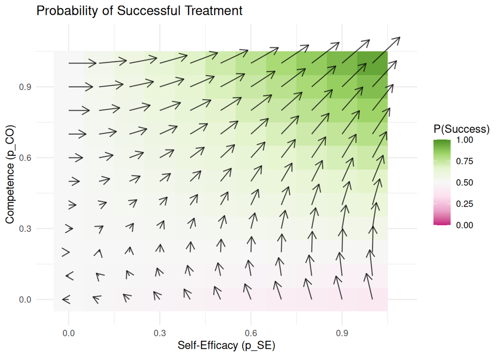

```r
# Different treatment outcome probabilities
p_eS <- 0.95
p_iS <- 0.4
p_pS <- 0.5
g <- plot_heatmap_gradient(p_eS, p_iS, p_pS)
g
```

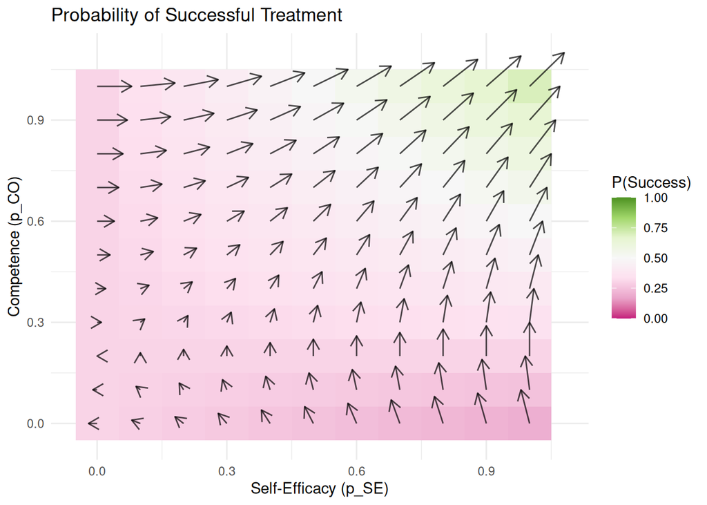

```r
# Different treatment outcome probabilities
p_eS <- 0.7
p_iS <- 0.2
p_pS <- 0.3
g <- plot_heatmap_gradient(p_eS, p_iS, p_pS)
g
```